# 廣義可重製：開放的科學研究協作模式

陳紹慶

## 1.構成協同合作要素

協同合作是人類能創造集體文明的動力，可以說只要有合適的條件，你我都能為相同的目標進行協同合作。許多對人類產生重大影響的科學研究成果，都是至少二位以上參與者協同合作的產物。簡單地說，廣義可重製的科學研究，成功條件只有一項：將研究開始到結束的協同合作過程完整公開。包括從開始確定具體假設，到發表實際成果之間的過程，產生的任何紀錄或資料，都是協同合作的證據。讓這些紀錄與資料以共同約定的標準產生與保存，他人能在評審研究成果或深度閱讀論文時，檢視研究過程中可能造成問題的細節。  
形成良好的協同合作，需要參與人員的執行意志與維持意志的措施。在這個版本裡，本文集中探討維持意志的措施。我主張一個有效維持執行意志的措施，就是每個步驟約定共同遵守的達成標準。例如確定獨變項A是操作刺激的三種呈現方式，備齊三種呈現方式的刺激物，就是參與人員要遵守的達成標準。 因為多數實驗操作的變項不只一樣，許多項目的達成標準需要使用版本控制系統管理，才能給予參與人員達成目標的彈性。如何使用控制系統管理達成標準，資料編碼簿(codebook)是一件可運用的道具。談「狹義可重製」提到的資料編碼簿，是在開始收集資料之前，就應該準備好的文件。資料編碼簿的成形時機，是研究者已經確認所有納入的變項是要操作、控制、測量與準備進行控索性分析用的。變項的定義與資料內容來自研究的假設，以及方法設計。 因為資料編碼簿的結構性質，我建議研究者可利用自已熟悉的程式語言，撰寫生成資料編碼簿的程式碼，使用程式碼的註解模式，置入完成各欄位的達成標準。註解文字能輕易轉換成markdown文件，參與人員能立即運用於紀錄或報告，讓團隊即時得知最新進度。

## 2.如何維持協同合作

維持協同合作的關鍵在於參與者願意付諸實現的意志。不只是完成計畫目標，還有一起紀錄過程細節的意願。進行科學研究如同建築工程，需要進行一段時間，而且可能發生預期之外的狀況，需要調整執行細節或排除問題。發生考驗維持協同合作意志的狀況，也是有可能發生的情節。所幸網路社群平台的普及，已有促進各式專案的協同合作平台誕生，值得正在科學研究前沿奮鬥的研究者，花點工夫上手與適應。  
因為各種研究領域的工作模式不同，至今都還沒有誕生一套能適用所有科學研究工作者的協作平台。這個版本的主張最佳模式，是能整合研究者已經慣的協作工具，例如多數網路使用者都會註冊的google drive套件、同步不同電腦資料的Dropbox。有協作意識的研究團隊，都會使用這些工具交流研究資料。但是要維持協同合作的意願，這些工具並未設計讓參與人員檢視各項工作約定標準，以及達成狀況的自動紀錄。  
接下來介紹開放科學平台(osf.io)的角度，採用如何維持協同合作執行標準的角度，做為示範的取材方向。因為開放科學平台 尚未開發到穩定版本，現在示範的細節，很可能下次改版就會改變或失效。如果有這樣的情況，這份文件會更新內容，也請讀者留意並回饋給我。

## 3.開放科學平台:示範與訣竅

### (1)註冊

因為osf大量使用HTML5功能與google api，建議使用chrome瀏覽器連上[首頁](https://osf.io/)。第一次使用者請先註冊，在首頁右下的註冊欄(見下圖紅框處)，填入個人英文姓名、常用的電子郵件帳號與自設密碼。按下*Sign up free*之後，到自已的電子郵件信箱收取確認信。完成確認程序，就可以從首頁右上角的*Sign in*，填入電子郵件帳號與自設密碼，正式登入osf。

[figure not shown]

### (2)專案入口頁

首先展示我的登入頁畫面。

[figure not shown]

第一次登入的讀者看到的畫面會與上圖有些微差異，借此說明畫面中的介面功能。登入的畫面有三個主要介面:  
* 儀表板(Dashboard)  
列出使用者自行創建或加入的專案，以及收集未加入但公開的專案。儀表板的功能與操作方式，都很類似Windows系統的檔案總管。第一次登入的使用者，儀表板只有*All my registerations*與*All my projects*兩個項目。兩個項目都是資料夾，現在應該沒有任何專案。如果你正參與一項研究專案，請和你的夥伴推舉出一位專案領導人，由專案領導人負責開設一項新專案。當你自已開設專案，或者 專案領導人將你加入專案，就會在*All my projects*看到專案名稱，往後都可由此點擊進入你的專案。  
讀者也可以自行收集其它osf使用者建立的公開專案，畫面中的儀表板上方*Adding Existing Project*與*Search*都可以搜尋想收集的專案，找到並確認後，就會在*All my registerations*與*All my projects*之外，看到收集的專案名稱。使用者也可以自設資料夾*Add Collection*，分類集中收集的專案名稱。

- 快速功能列(Quick Tasks) 這裡包含四種功能：*前往專案頁面*(Go to my project)，*創建專案*(Create a Project)，*註冊專案*(Register a project)，以及*上傳檔案至專案*(Upload file(s))。  
  *前往專案頁面*的功能與從儀表板點擊專案名稱相同，只是這裡是自行輸入專案名稱，不過這裡還可鍵入專案內元件名稱，網頁會自動帶出符合輸入名稱的專案或元件連結，喜歡打字的使用者可以用此功能前往要作業的專案區域。  
  *創建專案*就是每一項專案領導人要做的第一步，只要輸入專案名稱(Title)，按下*Create*，一項專案頁面就會產生。其它兩項Description與Templete是自選設定，這個文件版本暫不介紹。也許讀書會想問：如果和別人的專案撞名怎麼辦？稍後「專案設計」將介紹osf的專案引用條(citation)，了解開發團隊如何解決問題。  
  *註冊專案*是將個人與夥伴維護的專案，註冊為封存專案。一項專案確定註冊後，會移到*All my registerations*。封存專案內容無法變更，且會完全公開，通常這是一項專案結束並完成發表之後，才會註冊封存。封存專案會成為開放取用的公共財產，其它研究者能運用封存專案內容建立新的研究專案，這也是目前已知廣義可重製的最佳模式。 *上傳檔案至專案*的視覺化操作界面，讓使用者能從個人上網設備，包含手機與平板，上傳資料至參與的專案。如果讀者手邊有可上網的手機或平板，可嘗試使用這項功能，上傳資料到osf，因為osf網頁是以跨平台框架設計。
- 專案更新提示(Watchlist) 這部份是針對你想追蹤的專案更新狀況。只要在自已或他人專案頁設定追蹤，專案的更新狀況會依時間順序列於此處，並可點擊連結至專案頁面。如何設定要追蹤的專案，在稍後的「專案設計」說明。  
  最後介紹畫面最上方的功能介面，這列功能介面在後續的任何操作，都會保持在畫面最上方。最左邊osf logo是往登入前畫面的連結，*My Dashboard*是指向上圖–剛登入的初始畫面。因此往後操作過程發現自已忘記作業目的，可點擊這兩個連結回到初始畫面。*Browse*是osf開發團隊推薦的三種專案搜尋模式，有興趣的讀者可以試試。*Help*顧名思義就是提供解決操作問題的指引，其中一項*Get Started*，整理開放科學中心釋出的osf示範影片，建議第一次使用的讀者先看看，部分專案元件的介紹會配合影片說明。*放大鏡*會顯示搜尋列，讓使用者根據關鍵字，尋找已登記在osf的專案。其後的*圖像與使用者姓名*連結使用者個人資訊設定頁面，圖像是使用者自訂或系統產生的隨機圖像。*齒輪*連結個人的帳戶設定頁面，包括變更密碼，之後的文件版本介紹如何設定add-on，會再介紹詳細功能。*登出*就是當你確定要從現在的上網設備登出osf，點此圖像即可。

### (3)專案設計

- 綜觀  
  下圖是我為示範而開啟的專案，名叫**Demo OSF Project**，畫面呈現一份專案的初始狀況。

[figure not shown]

與專案入口頁互動的功能有設定專案是私有(Private)或公開(Public)、加入儀表板(Add to Dashboard Folder)、追蹤(Watch)、還有複製專案(Duplicate)。從預設按鈕圖示可知，一項專案剛建立起時是私有的，只有參與專案的團隊成員才能觀看與修改內容，這些功能讓使用者可隨時切換為公開模式，背後的哲學是希望在osf上的專案能在達成一定程度就開放給全世界了解。  
加入儀表板功能讓使用者看過他人的專案，覺得有參考的價值，可點此按鈕加入收集，日後可隨時由儀表板回來觀看。  
追蹤功能開啟後，正在進行中的專案有任何更新，都會顯示入口頁的*專案更新提示(Watchlist)*。旁邊的數字，可讓專案參與者了解，有多少osf註冊使用者正在關注這項專案。  
複製專案(Duplicate)是讓其它osf註冊使用者，使用這份專案的架構或內容，產生一份新專案。按鈕上的數字顯示有多少osf使用者運用此專案去規劃新專案。因此對研究人員來說，這一系列功能有促進跨團隊交際的作用。  
接著就來一一介紹專案頁面上的每個元件。

- 專案說明文件百科(wiki)  
  每個專案元件必有一項說明文件管理集，下圖中是將入口頁的wiki展開後的畫面。

[figure not shown]

  說明文件是以markdown格式編輯，讀者可參考[Markdown語法說明](http://markdown.tw/)，認識如何編輯markdown文件。順便一提，本書所有文件都是用markdown格式編輯。osf提供線上markdown編輯器，如果你要編輯畫面中*Home*的文件內容，按下右上角的*edit*，就會開啟如以下畫面右邊的線上編輯器視窗：

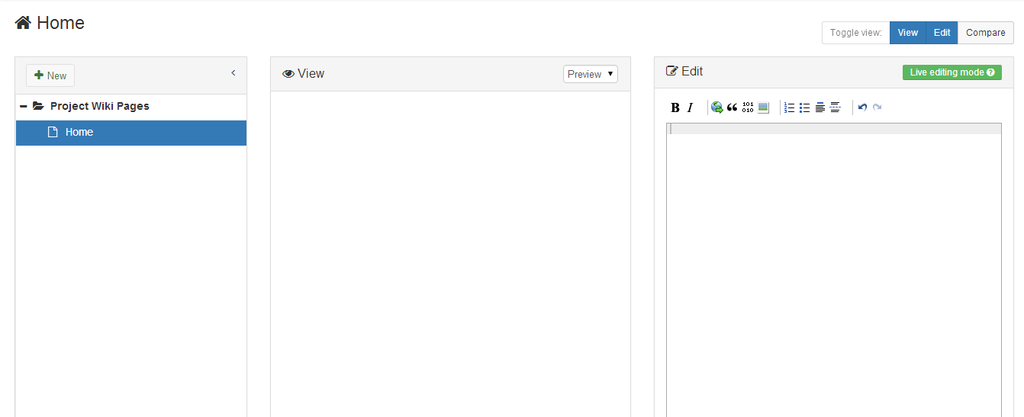

osf的線上編輯器是所見即所得，你在*Edit*視窗編輯的內容，都可以在中間的*View*視窗看到成果。編輯器支援版本控制，所以你不必打幾個字就存檔，完成到一定進度再存檔即可。每次存檔osf都會留一份版本備份，你可以按右上角的*Compare*，比對前後版本的內容。因為osf專案說明文件有這些功能，我強烈推薦團隊成員約定的執行標準，放在osf專案wiki管理。osf開發團隊提供一段[編輯器示範錄像](https://www.youtube.com/watch?v=BWlRGvg3Ro4)，建議讀者看看其中示範的特別功能  
最後來看畫面左邊的文件管理視窗，每個專案元件剛建立時都會有一個空白的*Home*文件，*Home*文件的內容會顯示在專案初始畫面的wiki視窗中。使用者可以根據需要編輯內容或增加新的說明文件，我的建議是*Home*文件放置參與成員都要留意的訊息，像是執行標準和進度。讀者如果想在自已開設的專案建立wiki之前，先熟悉編輯程序，可以利用配合本書的[示範專案](https://osf.io/smunw/)，我已設定任何osf使用者可自行編輯這項專案的wiki

- 專案引用條(citation)  
  專案入口頁的右邊有一個收起來的小視窗*citiation*，視窗邊框還有這項專案的專屬網址。讀者展開視窗，會發現這個專案名稱與現在的貢獻者，以三種常見的文獻格式顯示。這讓參與人員或其他人士能在正式報告中，合法引用這項專案。讀者如果更用心，可以google這個專案看看。

  ```
  APA
  Chen, S.-C. (2015, October 13). Demo OSF Project. Retrieved from osf.io/smunw
  MLA
  Chen, Sau-Chin. “Demo OSF Project.” Open Science Framework, 13 Oct. 2015. Web.
  Chicago
  Chen, Sau-Chin. 2015. “Demo OSF Project.” Open Science Framework. October 13. osf.io/smunw.
  ```

- 檔案總管(Files)  
  如果使用者有檔案要上傳，可以把這部分當成另一個檔案總管，個人電腦裡的資料可拖移至儀表板中的專案連結，完成檔案上傳。相對地也可以由此下載專案之內的檔案。現在的osf還提供資料夾打包下載功能(download as zip)，可以一次下載整個元件之內的檔案。

[figure not shown]

  點一下檔案總管裡的*OSF Storage*，會看到上方出現5個功能按鈕。熟悉檔案總管的讀者，可以了解能由此上下傳檔案，或增加資料夾。因此研究團隊可以彈性管理過程中產生的資料，配合wiki說明文件，讓參與人員了解如何管理各式資料。  
  如果使用者習慣把研究資料存放在其它雲端資料夾，例如dropbox, google雲端硬碟等，檔案總管能與之連結，方便團隊管理。詳細的設定方法請見[文件與錄影範例](https://osf.io/getting-started/#addons)。
- 專案元件(Components)  
  剛建立的專案只有一個空白的*Component*小視窗，確定要增加的專案元件，就按下*Add Components*按鈕，接著出現如下圖的互動視窗。

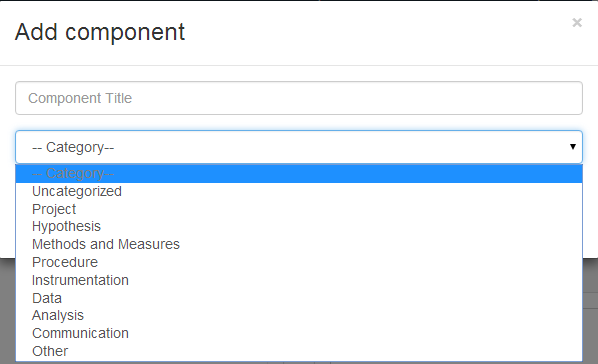

  讀者會看到增加專案元件很容易，關鍵是為這項元件命名與分類。osf已提供如圖中看到的分類標籤，如果建立專案時已經有完整的計畫書，應當了解要建立多少元件，還有要如何分類。這也可以看到osf開發團隊對協同合作的想像，紀錄團隊成員的參與其中的活動經驗，一項研究專案從假設進行到結論的一切過程。  
  此外，已經存在的專案，也可以成為新建專案的元件。方法是按下*Component*小視窗上面的*Add Links*按鈕，會出現如下圖的互動視窗。用關鍵字搜尋到要加入的專案，按下*Add Link*按鈕，最後按右下角的*Add*，就會成為現在專案的一個元件。這種方式可用在前一個專案是後一個專案的pilot study，後案規劃完整後，將前案納入管理。

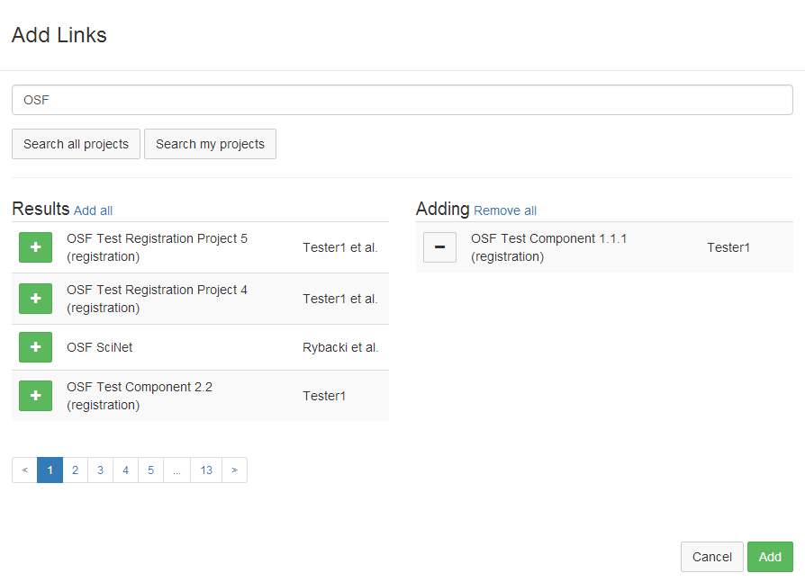

- 標籤(Tags)  
  標籤相當於一篇論文的關鍵詞(Keywords)，如果專案設定為公開，其它使用者可以透過搜尋找到這項專案。研究團隊可以從建立知識連結的角度，設定專案的標籤，與某個重要的研究專案有相同的標籤，能增加其它研究者對此專案的興趣。osf的好處是沒有限制標籤的數量，因此可以設定描述細節的名詞為標籤。
- 活動紀錄(Recent Activity)  
  參與成員在專案的任何元件之內，進行任何改變專案內容的活動，無論是新增或刪除wiki文字或檔案，都會在*活動紀錄*視窗累積一條紀錄。例如下圖的網頁快照，顯示我開啟這項示範專案，以及設定為公開的日期時間。

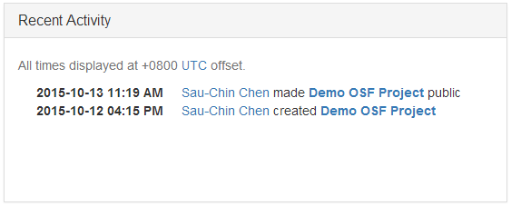